# Persuasion

## Explore Dialogue

First load the file and libraries.

```r
library(readr)
library(ggplot2)
library(tidyr)
```

When loading the files, remember to change the path to the directories in your computer.

### Cleaning the data

Many people started the interaction but did not finish.Therefore `dems` will be cleaned up and stored in a variable called `pre.good`

```r
# Exclude ppl that did not finish.
pre.good<-dems[dems$sessionID %in% post$sessionID,]
# Exclude test users
pre.good<-pre.good[pre.good$userType!="test",]
post<-post[post$sessionID %in% pre.good$sessionID,]

#Exclude those before Feb 23
pp<-Dialogue[Dialogue$sessionID %in% pre.good$sessionID,c("time","sessionID")]
pp.beforeFeb <- pp[c(67:2202),]
pre.good.sid<-unique(unlist(pre.good$sessionID, use.names = FALSE))
Dialogue <- Dialogue[Dialogue$sessionID %in% pre.good$sessionID,]
#View(pre.good)
```

We can also assign variables based on computations. For example, I will assign a number for the average **TaiChi interest** in the pre-survey, and one for the post-survey. Then I will plot them.

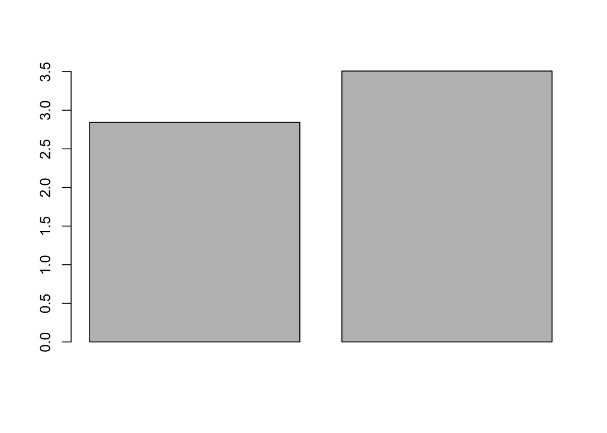

```r
interest.pre <- mean(dems$taichi_interest)
interest.post<- mean(post$taichi_learn)
need.pre <- mean(dems$taichi_interest)
need.post<- mean(post$taichi_learn)
barplot(c(interest.pre,interest.post))
```

```r
d <- cbind(c("Need Pre","Need Post", "Interest Pre", "Interest Post"),c(need.pre,need.post,interest.pre,interest.post))
```

And then, a prettier plot:

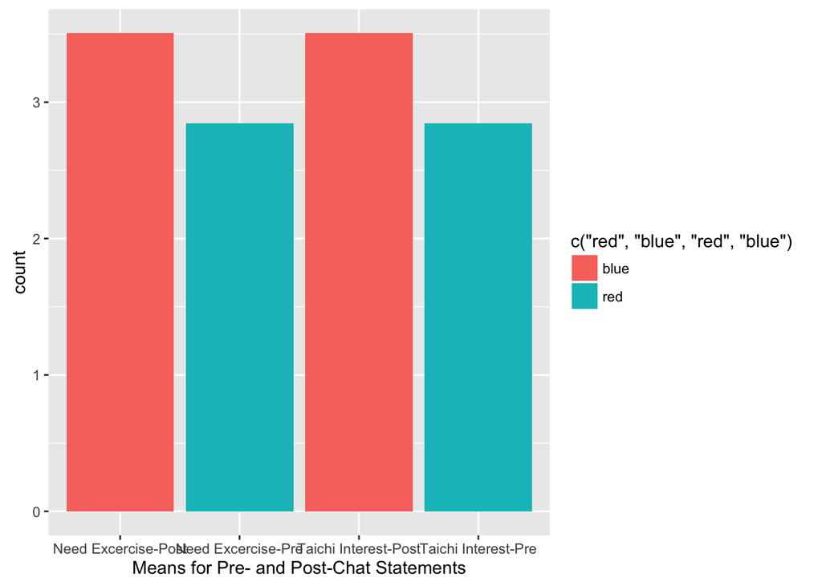

```r
qplot(x=c("Need Excercise-Pre","Need Excercise-Post", "Taichi Interest-Pre", "Taichi Interest-Post"),weight=c(need.pre,need.post,interest.pre,interest.post),xlab="Means for Pre- and Post-Chat Statements", fill=c("red","blue","red", "blue"))
```

And a t-test:

```r
t.test(pre.good$taichi_interest,post$taichi_learn,paired=TRUE)
```

```
##
##  Paired t-test
##
## data:  pre.good$taichi_interest and post$taichi_learn
## t = -2.9022, df = 62, p-value = 0.005125
## alternative hypothesis: true difference in means is not equal to 0
## 95 percent confidence interval:
##  -0.9650189 -0.1778383
## sample estimates:
## mean of the differences
##              -0.5714286
```

### More complicated selections of variables

Let’s see what is the usage of strategies in one user (identified by session ID.)

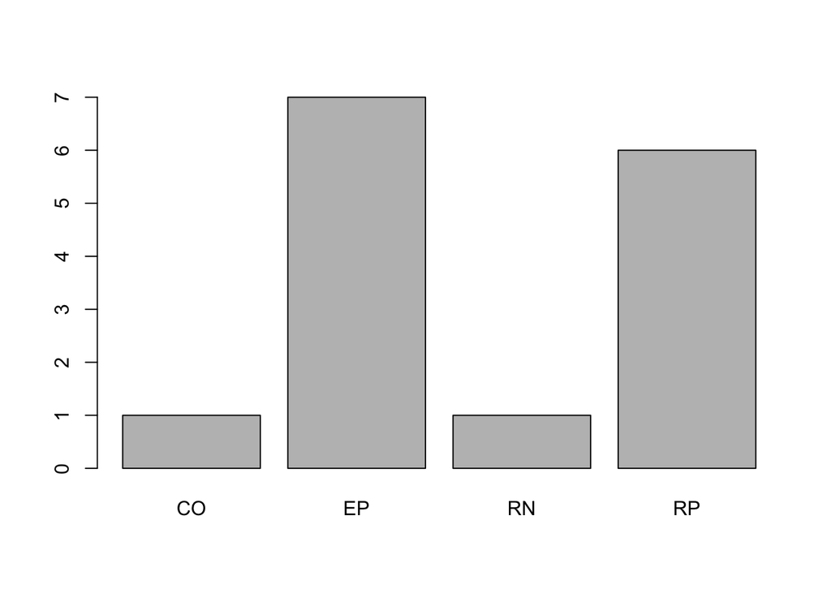

```r
barplot(table(Dialogue$strategy[Dialogue$sessionID=="ceprtq01ps0n5q92h8r74emid4" & Dialogue$speaker=="U"]))
```

Did the system understand the users?

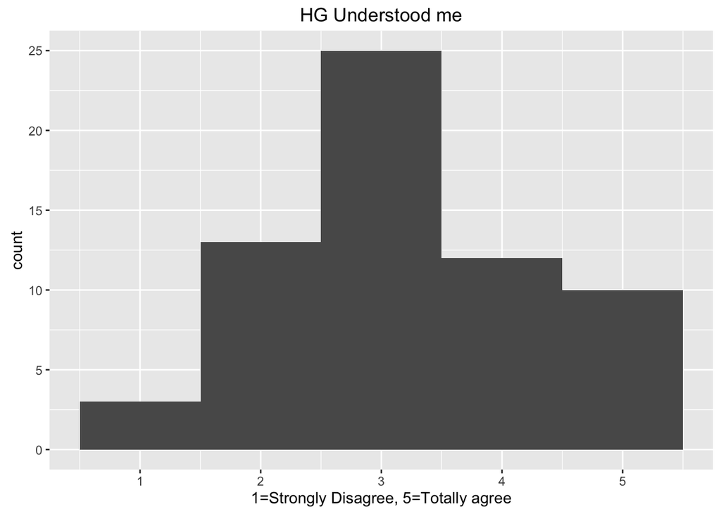

```r
qplot(data=post, x=guru_understanding, binwidth=1, xlab="1=Strongly Disagree, 5=Totally agree",main="HG Understood me")
```

### Running previous research analyisis on new data

Creating Print and visited group variables

```r
visited.pre <- pre.good[pre.good$ID %in% visited$ID,]
visited.post <- post[post$sessionID %in% visited.pre$sessionID,]
visited.dialogues <- Dialogue[Dialogue$sessionID %in% visited.pre$sessionID,]
```

Creating Print group variables

```r
printed.post <- post[post$printed_flyer==1,]
printed.pre <- pre.good[pre.good$sessionID %in% printed.post$sessionID,]
printed.dialogues <- Dialogue[Dialogue$sessionID %in% printed.post$sessionID,]
```

How many people printed?

```r
length(printed.pre$sessionID)
```

```
## [1] 31
```

What percentage of people printed

```r
length(printed.pre$sessionID)/length(pre.good$sessionID) * 100
```

```
## [1] 49.20635
```

Demographics stats - Now we check basic demographics: Grad/U-Grad/Staff; Ethnicity and Gender.

#### Position

- 1:U-grad
- 2:Grad
- 3:Faculty
- 4:Staff

#### Age

- 1:18-21
- 2:22-25
- 3:26-30
- 4:31-40
- 5:41-50
- 6:51-60
- 7:61+

#### Ethnicity

- 1:Caucasian
- 2:Hispanic/Latino
- 3:Middle Eastern
- 4:Asian Pacific Islander
- 5: Black/African American
- 6:Other

```r
table(pre.good$position)
```

```
##
##  1  2  3  4
## 52  9  1  1
```

```r
table(pre.good$gender)
```

```
##
##  1  2  3
## 46 16  1
```

```r
table(pre.good$ethnicity)
```

```
##
##  1  2  3  4  5  6
## 14 17  2 19  6  5
```

```r
table(pre.good$age_range)
```

```
##
##  1  2  3  4  5
## 12 26 11 12  2
```

Now, in percentages:

```r
table(pre.good$position)/length(pre.good$position)
```

```
##
##          1          2          3          4
## 0.82539683 0.14285714 0.01587302 0.01587302
```

```r
table(pre.good$gender)/length(pre.good$gender)
```

```
##
##          1          2          3
## 0.73015873 0.25396825 0.01587302
```

```r
table(pre.good$ethnicity)/length(pre.good$ethnicity)
```

```
##
##          1          2          3          4          5          6
## 0.22222222 0.26984127 0.03174603 0.30158730 0.09523810 0.07936508
```

```r
table(pre.good$age_range)/length(pre.good$age_range)
```

```
##
##          1          2          3          4          5
## 0.19047619 0.41269841 0.17460317 0.19047619 0.03174603
```

What percentage of people were under 40 years old?

```r
 length(pre.good[pre.good$age_range<5,]$sessionID)/length(pre.good$sessionID)*100
```

```
## [1] 96.8254
```

What was the modal age range?

```r
tail(names(sort(table(pre.good$age_range))), 1)
```

```
## [1] "2"
```

Compare post and pre chat desire to do excercise

```r
pre.desire <- pre.good$excercise_need
post.desire <- - post$post_excercise_need
t.test(pre.desire,post.desire,paired=TRUE)
```

```
##
##  Paired t-test
##
## data:  pre.desire and post.desire
## t = 34.708, df = 62, p-value < 2.2e-16
## alternative hypothesis: true difference in means is not equal to 0
## 95 percent confidence interval:
##  7.419574 8.326457
## sample estimates:
## mean of the differences
##                7.873016
```

Compare post and pre chat interest in learning taichi

```r
pre.interest <- pre.good$taichi_interest
post.interest <- - post$taichi_learn
t.test(pre.interest,post.interest,paired=TRUE)
```

```
##
##  Paired t-test
##
## data:  pre.interest and post.interest
## t = 25, df = 62, p-value < 2.2e-16
## alternative hypothesis: true difference in means is not equal to 0
## 95 percent confidence interval:
##  5.929150 6.959739
## sample estimates:
## mean of the differences
##                6.444444
```

Taichi interest table

```r
raw_merged = merge(x = pre.good, y = post, by = "sessionID", all = TRUE)

printed.decreased.interest <- length(raw_merged[raw_merged$taichi_learn < raw_merged$taichi_interest & raw_merged$printed_flyer == 1,]$sessionID)

printed.increased.interest <- length(raw_merged[raw_merged$taichi_learn > raw_merged$taichi_interest & raw_merged$printed_flyer == 1,]$sessionID)

printed.same.interest <- length(raw_merged[raw_merged$taichi_learn == raw_merged$taichi_interest & raw_merged$printed_flyer == 1,]$sessionID)

nprinted.decreased.interest <- length(raw_merged[raw_merged$taichi_learn < raw_merged$taichi_interest & raw_merged$printed_flyer == 0,]$sessionID)

nprinted.increased.interest <- length(raw_merged[raw_merged$taichi_learn > raw_merged$taichi_interest & raw_merged$printed_flyer == 0,]$sessionID)

nprinted.same.interest <- length(raw_merged[raw_merged$taichi_learn == raw_merged$taichi_interest & raw_merged$printed_flyer == 0,]$sessionID)

c1 <- c("", "Decreased", "Remained Same", "Increased", "Total")

c2 <- c ("No", nprinted.decreased.interest, nprinted.same.interest, nprinted.increased.interest, nprinted.decreased.interest + nprinted.same.interest + nprinted.increased.interest)

c3 <- c ("Yes", printed.decreased.interest, printed.same.interest, printed.increased.interest, printed.decreased.interest + printed.same.interest + printed.increased.interest)

c4 <- c ("Total", printed.decreased.interest + nprinted.decreased.interest, printed.same.interest + nprinted.same.interest, printed.increased.interest+nprinted.increased.interest, length(pre.good$sessionID))

print.interest <- data.frame(c1, c2, c3, c4)
```

Creating PINT Group variables

```r
pint.merged <-raw_merged[raw_merged$taichi_learn > raw_merged$taichi_interest & raw_merged$printed_flyer == 1,]
```

Creating nonPINT Group variables

```r
npint.merged <-raw_merged[raw_merged$taichi_learn <= raw_merged$taichi_interest |  raw_merged$printed_flyer == 0,]
```

How many participants printed and reported an increased interest in taichi after the dialogue?

```r
length(pint.merged$sessionID)
```

```
## [1] 14
```

```r
length(pint.merged$sessionID)/length(pre.good$sessionID) * 100
```

```
## [1] 22.22222
```

Out of the people who printed, how many had an increased interest in taichi post chat?

```r
length(pint.merged$sessionID)
```

```
## [1] 14
```

```r
length(printed.pre$sessionID)
```

```
## [1] 31
```

Out of the people who printed, what was the percentage of people who had an increased interest in taichi post chat?

```r
length(pint.merged$sessionID)/length(printed.pre$sessionID) * 100
```

```
## [1] 45.16129
```

Was there a significant difference between PINT and non-PINT groups’ pre chat taichi interest?

```r
t.test(pint.merged$taichi_interest, npint.merged$taichi_interest)
```

```
##
##  Welch Two Sample t-test
##
## data:  pint.merged$taichi_interest and npint.merged$taichi_interest
## t = -0.72299, df = 42.268, p-value = 0.4737
## alternative hypothesis: true difference in means is not equal to 0
## 95 percent confidence interval:
##  -0.7349475  0.3471924
## sample estimates:
## mean of x mean of y
##  2.785714  2.979592
```

Was there a significant difference between PINT and non-PINT groups’ post chat taichi interest?

```r
t.test(pint.merged$taichi_learn, npint.merged$taichi_learn)
```

```
##
##  Welch Two Sample t-test
##
## data:  pint.merged$taichi_learn and npint.merged$taichi_learn
## t = 4.2198, df = 39.177, p-value = 0.0001403
## alternative hypothesis: true difference in means is not equal to 0
## 95 percent confidence interval:
##  0.6163827 1.7509643
## sample estimates:
## mean of x mean of y
##  4.428571  3.244898
```

Was there a significant difference between the percentages of EN utterences in PINT and non-PINT groups?

Was there a significant difference between the percentages of RN utterences in PINT and non-Pint groups?

```r
pint.en <- c()
npint.en <- c()
pint.rn <- c()
npint.rn <- c()
pint.ep <- c()
npint.ep <- c()
pint.rp <- c()
npint.rp <- c()
for (s in pint.merged$sessionID) {
  totalDialogues <- length(Dialogue[Dialogue$sessionID == s & Dialogue$speaker=="HG",])

  pint.en <- append(pint.en,(length(Dialogue[Dialogue$sessionID == s & Dialogue$speaker=="HG" & substr(Dialogue$q_id, 1, 2) == "EN",]$sessionID))/ totalDialogues)

   pint.rn <- append(pint.rn,(length(Dialogue[Dialogue$sessionID == s & Dialogue$speaker=="HG" & substr(Dialogue$q_id, 1, 2) == "RN",]$sessionID))/ totalDialogues)

   pint.ep <- append(pint.ep,(length(Dialogue[Dialogue$sessionID == s & Dialogue$speaker=="HG" & substr(Dialogue$q_id, 1, 2) == "EP",]$sessionID))/ totalDialogues)

   pint.rp <- append(pint.rp,(length(Dialogue[Dialogue$sessionID == s & Dialogue$speaker=="HG" & substr(Dialogue$q_id, 1, 2) == "RP",]$sessionID))/ totalDialogues)
}

for (s in npint.merged$sessionID) {
  totalDialogues <- length(Dialogue[Dialogue$sessionID == s & Dialogue$speaker=="HG",])

  npint.en <- append(npint.en,(length(Dialogue[Dialogue$sessionID == s & Dialogue$speaker=="HG" & substr(Dialogue$q_id, 1, 2) == "EN",]$sessionID))/ totalDialogues)

   npint.rn <- append(npint.rn,(length(Dialogue[Dialogue$sessionID == s & Dialogue$speaker=="HG" & substr(Dialogue$q_id, 1, 2) == "RN",]$sessionID))/ totalDialogues)

     npint.ep <- append(npint.ep,(length(Dialogue[Dialogue$sessionID == s & Dialogue$speaker=="HG" & substr(Dialogue$q_id, 1, 2) == "EP",]$sessionID))/ totalDialogues)

   npint.rp <- append(npint.rp,(length(Dialogue[Dialogue$sessionID == s & Dialogue$speaker=="HG" & substr(Dialogue$q_id, 1, 2) == "RP",]$sessionID))/ totalDialogues)
}

t.test(pint.en, npint.en)
```

```
##
##  Welch Two Sample t-test
##
## data:  pint.en and npint.en
## t = -1.2167, df = 47.715, p-value = 0.2297
## alternative hypothesis: true difference in means is not equal to 0
## 95 percent confidence interval:
##  -0.05027217  0.01237130
## sample estimates:
##  mean of x  mean of y
## 0.01020408 0.02915452
```

```r
t.test(pint.rn, npint.rn)
```

```
##
##  Welch Two Sample t-test
##
## data:  pint.rn and npint.rn
## t = 0.056946, df = 40.811, p-value = 0.9549
## alternative hypothesis: true difference in means is not equal to 0
## 95 percent confidence interval:
##  -0.05024662  0.05316207
## sample estimates:
## mean of x mean of y
## 0.1326531 0.1311953
```

```r
t.test(pint.ep, npint.ep)
```

```
##
##  Welch Two Sample t-test
##
## data:  pint.ep and npint.ep
## t = -1.2173, df = 31.203, p-value = 0.2326
## alternative hypothesis: true difference in means is not equal to 0
## 95 percent confidence interval:
##  -0.30414842  0.07674318
## sample estimates:
## mean of x mean of y
##  1.020408  1.134111
```

```r
t.test(pint.rp, npint.rp)
```

```
##
##  Welch Two Sample t-test
##
## data:  pint.rp and npint.rp
## t = 1.1148, df = 26.999, p-value = 0.2748
## alternative hypothesis: true difference in means is not equal to 0
## 95 percent confidence interval:
##  -0.07596833  0.25672635
## sample estimates:
## mean of x mean of y
## 0.9183673 0.8279883
```

Find the correlation between the number of EN,EP,RP,RN utterences and pre and post taichi chat interest

```r
  en.count <- c()
  ep.count <- c()
  rp.count <- c()
  rn.count <- c()
for (s in  raw_merged$sessionID) {
  en.count <- append(en.count,length(Dialogue[Dialogue$sessionID == s & Dialogue$speaker=="HG" & substr(Dialogue$q_id, 1, 2) == "EN",]$sessionID))
  rn.count <- append(rn.count,length(Dialogue[Dialogue$sessionID == s & Dialogue$speaker=="HG" & substr(Dialogue$q_id, 1, 2) == "RN",]$sessionID))
  ep.count <- append(ep.count,length(Dialogue[Dialogue$sessionID == s & Dialogue$speaker=="HG" & substr(Dialogue$q_id, 1, 2) == "EP",]$sessionID))
  rp.count <- append(rp.count,length(Dialogue[Dialogue$sessionID == s & Dialogue$speaker=="HG" & substr(Dialogue$q_id, 1, 2) == "RP",]$sessionID))
}


  cor.test(ep.count, raw_merged$taichi_interest)
```

```
##
##  Pearson's product-moment correlation
##
## data:  ep.count and raw_merged$taichi_interest
## t = -2.2289, df = 61, p-value = 0.02951
## alternative hypothesis: true correlation is not equal to 0
## 95 percent confidence interval:
##  -0.48894866 -0.02860942
## sample estimates:
##        cor
## -0.2744292
```

```r
  cor.test(rp.count, raw_merged$taichi_interest)
```

```
##
##  Pearson's product-moment correlation
##
## data:  rp.count and raw_merged$taichi_interest
## t = 1.5277, df = 61, p-value = 0.1318
## alternative hypothesis: true correlation is not equal to 0
## 95 percent confidence interval:
##  -0.05859181  0.41976072
## sample estimates:
##       cor
## 0.1919599
```

```r
  cor.test(en.count, raw_merged$taichi_interest)
```

```
##
##  Pearson's product-moment correlation
##
## data:  en.count and raw_merged$taichi_interest
## t = -1.044, df = 61, p-value = 0.3006
## alternative hypothesis: true correlation is not equal to 0
## 95 percent confidence interval:
##  -0.3681722  0.1191843
## sample estimates:
##        cor
## -0.1324932
```

```r
  cor.test(rn.count, raw_merged$taichi_interest)
```

```
##
##  Pearson's product-moment correlation
##
## data:  rn.count and raw_merged$taichi_interest
## t = 2.0527, df = 61, p-value = 0.0444
## alternative hypothesis: true correlation is not equal to 0
## 95 percent confidence interval:
##  0.006857738 0.472215931
## sample estimates:
##       cor
## 0.2541909
```

```r
  cor.test(ep.count, raw_merged$taichi_learn)
```

```
##
##  Pearson's product-moment correlation
##
## data:  ep.count and raw_merged$taichi_learn
## t = -3.9955, df = 61, p-value = 0.0001764
## alternative hypothesis: true correlation is not equal to 0
## 95 percent confidence interval:
##  -0.6318980 -0.2340868
## sample estimates:
##        cor
## -0.4554372
```

```r
  cor.test(rp.count, raw_merged$taichi_learn)
```

```
##
##  Pearson's product-moment correlation
##
## data:  rp.count and raw_merged$taichi_learn
## t = 0.87188, df = 61, p-value = 0.3867
## alternative hypothesis: true correlation is not equal to 0
## 95 percent confidence interval:
##  -0.1406892  0.3491118
## sample estimates:
##       cor
## 0.1109431
```

```r
  cor.test(en.count, raw_merged$taichi_learn)
```

```
##
##  Pearson's product-moment correlation
##
## data:  en.count and raw_merged$taichi_learn
## t = -2.7667, df = 61, p-value = 0.007485
## alternative hypothesis: true correlation is not equal to 0
## 95 percent confidence interval:
##  -0.53722546 -0.09390917
## sample estimates:
##        cor
## -0.3339051
```

```r
  cor.test(rn.count, raw_merged$taichi_learn)
```

```
##
##  Pearson's product-moment correlation
##
## data:  rn.count and raw_merged$taichi_learn
## t = 1.9783, df = 61, p-value = 0.05241
## alternative hypothesis: true correlation is not equal to 0
## 95 percent confidence interval:
##  -0.002363828  0.465019441
## sample estimates:
##      cor
## 0.245545
```

```r
Strategy <- c("EP", "RP", "EN", "RN" )
Taichi.Interest.pre <- c(-0.2744292,0.1919599,-0.1324932,0.2541909 )
Taichi.Interest.post <- c(-0.4554372,0.1109431,-0.3339051,0.245545)
df <- data.frame(Strategy,Taichi.Interest.pre, Taichi.Interest.post)
knitr::kable(head(df))
```

| Strategy | Taichi.Interest.pre | Taichi.Interest.post |
| --- | --- | --- |
| EP | -0.2744292 | -0.4554372 |
| RP | 0.1919599 | 0.1109431 |
| EN | -0.1324932 | -0.3339051 |
| RN | 0.2541909 | 0.2455450 |

Correlation between taihi interest (post-pre/increase) and the number of ep,rp,en,rn utterences

```r
  interest.increase <-raw_merged$taichi_learn - raw_merged$taichi_interest
  cor.test(ep.count, interest.increase)
```

```
##
##  Pearson's product-moment correlation
##
## data:  ep.count and interest.increase
## t = -1.8984, df = 61, p-value = 0.06238
## alternative hypothesis: true correlation is not equal to 0
## 95 percent confidence interval:
##  -0.45719911  0.01229546
## sample estimates:
##        cor
## -0.2361891
```

```r
  cor.test(rp.count, interest.increase)
```

```
##
##  Pearson's product-moment correlation
##
## data:  rp.count and interest.increase
## t = -0.5881, df = 61, p-value = 0.5586
## alternative hypothesis: true correlation is not equal to 0
## 95 percent confidence interval:
##  -0.3169540  0.1759529
## sample estimates:
##         cor
## -0.07508547
```

```r
  cor.test(en.count, interest.increase)
```

```
##
##  Pearson's product-moment correlation
##
## data:  en.count and interest.increase
## t = -1.9822, df = 61, p-value = 0.05197
## alternative hypothesis: true correlation is not equal to 0
## 95 percent confidence interval:
##  -0.465392713  0.001887465
## sample estimates:
##        cor
## -0.2459926
```

```r
  cor.test(rn.count, interest.increase)
```

```
##
##  Pearson's product-moment correlation
##
## data:  rn.count and interest.increase
## t = 0.11503, df = 61, p-value = 0.9088
## alternative hypothesis: true correlation is not equal to 0
## 95 percent confidence interval:
##  -0.2338914  0.2615378
## sample estimates:
##        cor
## 0.01472705
```

Correlation between the number of emotional utterences and guru’s understanding

```r
cor.test(ep.count+en.count, raw_merged$guru_understanding)
```

```
##
##  Pearson's product-moment correlation
##
## data:  ep.count + en.count and raw_merged$guru_understanding
## t = -2.7572, df = 61, p-value = 0.007681
## alternative hypothesis: true correlation is not equal to 0
## 95 percent confidence interval:
##  -0.53640826 -0.09277113
## sample estimates:
##        cor
## -0.3328847
```

Correlation between the number of rational utterences and guru’s understanding

```r
cor.test(rp.count+rn.count, raw_merged$guru_understanding)
```

```
##
##  Pearson's product-moment correlation
##
## data:  rp.count + rn.count and raw_merged$guru_understanding
## t = 0.90683, df = 61, p-value = 0.3681
## alternative hypothesis: true correlation is not equal to 0
## 95 percent confidence interval:
##  -0.1363282  0.3530101
## sample estimates:
##       cor
## 0.1153325
```

Correlation between increase in taichi interest and the number of emotional utterences

```r
cor.test(ep.count+en.count, interest.increase)
```

```
##
##  Pearson's product-moment correlation
##
## data:  ep.count + en.count and interest.increase
## t = -2.101, df = 61, p-value = 0.03978
## alternative hypothesis: true correlation is not equal to 0
## 95 percent confidence interval:
##  -0.4768455 -0.0128322
## sample estimates:
##        cor
## -0.2597713
```

Correlation between increase in taichi interest and the number of rational utterences

```r
cor.test(rp.count+rn.count, interest.increase)
```

```
##
##  Pearson's product-moment correlation
##
## data:  rp.count + rn.count and interest.increase
## t = -0.49045, df = 61, p-value = 0.6256
## alternative hypothesis: true correlation is not equal to 0
## 95 percent confidence interval:
##  -0.3056911  0.1880117
## sample estimates:
##         cor
## -0.06267283
```

Correlation between increase in taichi interest and the number of positive utterences

```r
cor.test(ep.count+rp.count, interest.increase)
```

```
##
##  Pearson's product-moment correlation
##
## data:  ep.count + rp.count and interest.increase
## t = -2.072, df = 61, p-value = 0.0425
## alternative hypothesis: true correlation is not equal to 0
## 95 percent confidence interval:
##  -0.474064571 -0.009239428
## sample estimates:
##        cor
## -0.2564175
```

Correlation between increase in taichi interest and the number of negative utterences

```r
cor.test(en.count+rn.count, interest.increase)
```

```
##
##  Pearson's product-moment correlation
##
## data:  en.count + rn.count and interest.increase
## t = -0.97557, df = 61, p-value = 0.3331
## alternative hypothesis: true correlation is not equal to 0
## 95 percent confidence interval:
##  -0.3606354  0.1277427
## sample estimates:
##        cor
## -0.1239452
```

Correlation between the need to excercise pre chat and taichi interest pre chat

```r
cor.test(raw_merged$excercise_need, raw_merged$taichi_interest)
```

```
##
##  Pearson's product-moment correlation
##
## data:  raw_merged$excercise_need and raw_merged$taichi_interest
## t = 2.2269, df = 61, p-value = 0.02966
## alternative hypothesis: true correlation is not equal to 0
## 95 percent confidence interval:
##  0.02835823 0.48875735
## sample estimates:
##       cor
## 0.2741967
```

Correlation between the need to excersice post chat and taichi interest post chat

```r
cor.test(raw_merged$post_excercise_need, raw_merged$taichi_learn)
```

```
##
##  Pearson's product-moment correlation
##
## data:  raw_merged$post_excercise_need and raw_merged$taichi_learn
## t = 7.671, df = 61, p-value = 1.621e-10
## alternative hypothesis: true correlation is not equal to 0
## 95 percent confidence interval:
##  0.5481104 0.8081722
## sample estimates:
##       cor
## 0.7007164
```

Correlation between the need to excercise pre chat and taichi interest post chat

```r
cor.test(raw_merged$excercise_need, raw_merged$taichi_learn)
```

```
##
##  Pearson's product-moment correlation
##
## data:  raw_merged$excercise_need and raw_merged$taichi_learn
## t = 3.4155, df = 61, p-value = 0.001138
## alternative hypothesis: true correlation is not equal to 0
## 95 percent confidence interval:
##  0.1697584 0.5898776
## sample estimates:
##       cor
## 0.4006711
```

Is the need to excercise post chat significantly different than the need to excercise pre chat?

```r
t.test(raw_merged$post_excercise_need, raw_merged$excercise_need)
```

```
##
##  Welch Two Sample t-test
##
## data:  raw_merged$post_excercise_need and raw_merged$excercise_need
## t = -2.2292, df = 118.18, p-value = 0.02769
## alternative hypothesis: true difference in means is not equal to 0
## 95 percent confidence interval:
##  -0.83926098 -0.04962791
## sample estimates:
## mean of x mean of y
##  3.714286  4.158730
```

Correlation between the guru’s understanding and increase in taichi interest

```r
cor.test(raw_merged$guru_understanding, interest.increase)
```

```
##
##  Pearson's product-moment correlation
##
## data:  raw_merged$guru_understanding and interest.increase
## t = 3.2905, df = 61, p-value = 0.001665
## alternative hypothesis: true correlation is not equal to 0
## 95 percent confidence interval:
##  0.1554387 0.5802036
## sample estimates:
##       cor
## 0.3882513
```

Correlation between the guru’s understanding and post taichi interest

```r
cor.test(raw_merged$guru_understanding, raw_merged$taichi_learn)
```

```
##
##  Pearson's product-moment correlation
##
## data:  raw_merged$guru_understanding and raw_merged$taichi_learn
## t = 2.9706, df = 61, p-value = 0.004247
## alternative hypothesis: true correlation is not equal to 0
## 95 percent confidence interval:
##  0.1181421 0.5544314
## sample estimates:
##       cor
## 0.3555011
```

Correlation between the guru’s understanding and post need to excercise

```r
cor.test(raw_merged$guru_understanding, raw_merged$post_excercise_need)
```

```
##
##  Pearson's product-moment correlation
##
## data:  raw_merged$guru_understanding and raw_merged$post_excercise_need
## t = 3.4244, df = 61, p-value = 0.001107
## alternative hypothesis: true correlation is not equal to 0
## 95 percent confidence interval:
##  0.1707689 0.5905558
## sample estimates:
##       cor
## 0.4015443
```

Correlation between the guru’s understanding and increase in need to excercise

```r
excercise_need.increase <-raw_merged$post_excercise_need - raw_merged$excercise_need
cor.test(raw_merged$guru_understanding, excercise_need.increase)
```

```
##
##  Pearson's product-moment correlation
##
## data:  raw_merged$guru_understanding and excercise_need.increase
## t = 2.108, df = 61, p-value = 0.03915
## alternative hypothesis: true correlation is not equal to 0
## 95 percent confidence interval:
##  0.01369202 0.47750967
## sample estimates:
##       cor
## 0.2605731
```

What are the main factors that correlate with Taichi interest post.

```r
summary(lm(raw_merged$taichi_learn~raw_merged$guru_understanding+raw_merged$excercise_need +raw_merged$post_excercise_need + raw_merged$taichi_persuation+raw_merged$age_range+raw_merged$excerise_freq))
```

```
##
## Call:
## lm(formula = raw_merged$taichi_learn ~ raw_merged$guru_understanding +
##     raw_merged$excercise_need + raw_merged$post_excercise_need +
##     raw_merged$taichi_persuation + raw_merged$age_range + raw_merged$excerise_freq)
##
## Residuals:
##     Min      1Q  Median      3Q     Max
## -2.4065 -0.2196  0.1207  0.3142  1.6934
##
## Coefficients:
##                                Estimate Std. Error t value Pr(>|t|)
## (Intercept)                    -0.60023    0.60426  -0.993  0.32482
## raw_merged$guru_understanding  -0.03469    0.09087  -0.382  0.70410
## raw_merged$excercise_need       0.04208    0.10307   0.408  0.68465
## raw_merged$post_excercise_need  0.32936    0.10536   3.126  0.00281 **
## raw_merged$taichi_persuation    0.69543    0.09376   7.417 7.07e-10 ***
## raw_merged$age_range           -0.02005    0.08369  -0.240  0.81151
## raw_merged$excerise_freq        0.24954    0.12721   1.962  0.05478 .
## ---
## Signif. codes:  0 '***' 0.001 '**' 0.01 '*' 0.05 '.' 0.1 ' ' 1
##
## Residual standard error: 0.6942 on 56 degrees of freedom
## Multiple R-squared:  0.7585, Adjusted R-squared:  0.7327
## F-statistic: 29.32 on 6 and 56 DF,  p-value: 1.344e-15
```

Were there significantly more negative dialogues in NPINT groups?

```r
t.test(npint.rn+npint.en, pint.rn+pint.en, alternative = "greater")
```

```
##
##  Welch Two Sample t-test
##
## data:  npint.rn + npint.en and pint.rn + pint.en
## t = 0.52736, df = 31.341, p-value = 0.3008
## alternative hypothesis: true difference in means is greater than 0
## 95 percent confidence interval:
##  -0.03872932         Inf
## sample estimates:
## mean of x mean of y
## 0.1603499 0.1428571
```

Were there significantly more positive dialogues in PINT groups?

```r
t.test(pint.rp+pint.ep, npint.rp+npint.ep, alternative = "greater")
```

```
##
##  Welch Two Sample t-test
##
## data:  pint.rp + pint.ep and npint.rp + npint.ep
## t = -0.27946, df = 59.389, p-value = 0.6096
## alternative hypothesis: true difference in means is greater than 0
## 95 percent confidence interval:
##  -0.1627797        Inf
## sample estimates:
## mean of x mean of y
##  1.938776  1.962099
```

Why did the need to exercise decrease after chat? 1. Interest in learning taichi substituted the decrease in the need to do to exercise? A. No, we found a significant correlation between the increase in the need to do exercise and interest in learning taichi.

```r
 cor.test(raw_merged$post_excercise_need - raw_merged$excercise_need, raw_merged$taichi_learn - raw_merged$taichi_interest)
```

```
##
##  Pearson's product-moment correlation
##
## data:  raw_merged$post_excercise_need - raw_merged$excercise_need and raw_merged$taichi_learn - raw_merged$taichi_interest
## t = 2.5262, df = 61, p-value = 0.01414
## alternative hypothesis: true correlation is not equal to 0
## 95 percent confidence interval:
##  0.06493149 0.51615456
## sample estimates:
##       cor
## 0.3077456
```

Q. Interest in learning taichi after the chat increased, then why did need to do exercise decrease if they both had a positive correlation?

```r
t.test(raw_merged$post_excercise_need, raw_merged$excercise_need, alternative = "greater")
```

```
##
##  Welch Two Sample t-test
##
## data:  raw_merged$post_excercise_need and raw_merged$excercise_need
## t = -2.2292, df = 118.18, p-value = 0.9862
## alternative hypothesis: true difference in means is greater than 0
## 95 percent confidence interval:
##  -0.7749832        Inf
## sample estimates:
## mean of x mean of y
##  3.714286  4.158730
```

```r
t.test(raw_merged$taichi_learn, raw_merged$taichi_interest, alternative = "greater",paired=T)
```

```
##
##  Paired t-test
##
## data:  raw_merged$taichi_learn and raw_merged$taichi_interest
## t = 3.9099, df = 62, p-value = 0.0001157
## alternative hypothesis: true difference in means is greater than 0
## 95 percent confidence interval:
##  0.3273909       Inf
## sample estimates:
## mean of the differences
##               0.5714286
```

2. Maybe this decrease in the “need to exercise” only happened for a certain group?

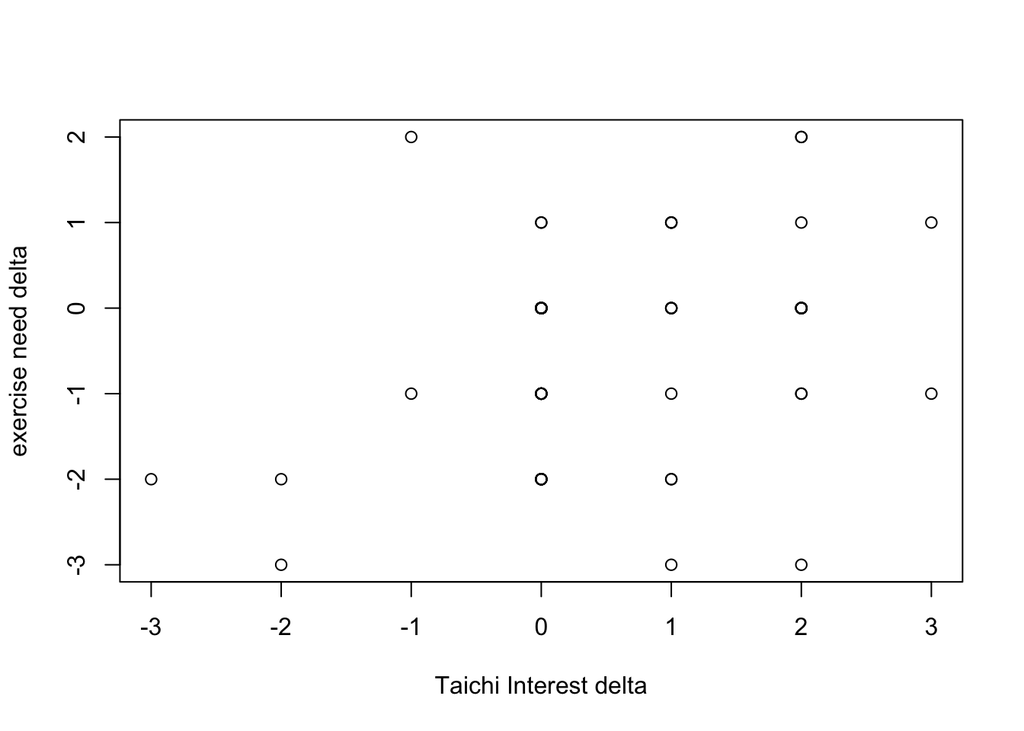

```r
plot(raw_merged$taichi_learn-raw_merged$taichi_interest,raw_merged$post_excercise_need-raw_merged$excercise_need,xlab="Taichi Interest delta",ylab="exercise need delta")
```

#### Exer Type

- 1 Aerobic
- 2 Anaerobic
- 3 Flexibility

#### Exer Frequency

- 1 0-1 times
- 2 2-3 times
- 3 4+ times

```r
aerobic <- raw_merged[raw_merged$excerise_time==1,]
anaerobic <- raw_merged[raw_merged$excerise_time==2,]
flexibility <- raw_merged[raw_merged$excerise_time==3,]

exer_freq_0 <- raw_merged[raw_merged$excerise_freq==1,]
exer_freq_2 <- raw_merged[raw_merged$excerise_freq==2,]
exer_freq_4 <- raw_merged[raw_merged$excerise_freq==3,]
```

- Did the need to exercise decrease for people who do aerobic exercise?

```r
t.test(aerobic$post_excercise_need, aerobic$excercise_need, alternative = "greater",paired=T)
```

```
##
##  Paired t-test
##
## data:  aerobic$post_excercise_need and aerobic$excercise_need
## t = -2.3738, df = 40, p-value = 0.9888
## alternative hypothesis: true difference in means is greater than 0
## 95 percent confidence interval:
##  -0.7504496        Inf
## sample estimates:
## mean of the differences
##              -0.4390244
```

- Did the need to exercise decrease for people who do anaerobic exercise?

```r
t.test(anaerobic$post_excercise_need, anaerobic$excercise_need, alternative = "greater",paired=T)
```

```
##
##  Paired t-test
##
## data:  anaerobic$post_excercise_need and anaerobic$excercise_need
## t = -1.8898, df = 17, p-value = 0.962
## alternative hypothesis: true difference in means is greater than 0
## 95 percent confidence interval:
##  -1.066952       Inf
## sample estimates:
## mean of the differences
##              -0.5555556
```

- Did the need to exercise decrease for people who do flexibility exercise?

```r
t.test(flexibility$post_excercise_need, flexibility$excercise_need, alternative = "greater",paired=T)
```

```
##
##  Paired t-test
##
## data:  flexibility$post_excercise_need and flexibility$excercise_need
## t = 0, df = 3, p-value = 0.5
## alternative hypothesis: true difference in means is greater than 0
## 95 percent confidence interval:
##  -0.9607566        Inf
## sample estimates:
## mean of the differences
##                       0
```

- Did the need to exercise decrease for people who exercise 0-1 times a week?

```r
t.test(exer_freq_0$post_excercise_need, exer_freq_0$excercise_need, alternative = "greater")
```

```
##
##  Welch Two Sample t-test
##
## data:  exer_freq_0$post_excercise_need and exer_freq_0$excercise_need
## t = -0.8824, df = 53.753, p-value = 0.8093
## alternative hypothesis: true difference in means is greater than 0
## 95 percent confidence interval:
##  -0.6759101        Inf
## sample estimates:
## mean of x mean of y
##  4.033333  4.266667
```

- Did the need to exercise decrease for people who exercise 2-3 times a week?

```r
t.test(exer_freq_2$post_excercise_need, exer_freq_2$excercise_need, alternative = "greater")
```

```
##
##  Welch Two Sample t-test
##
## data:  exer_freq_2$post_excercise_need and exer_freq_2$excercise_need
## t = -1.8815, df = 40.991, p-value = 0.9665
## alternative hypothesis: true difference in means is greater than 0
## 95 percent confidence interval:
##  -1.153122       Inf
## sample estimates:
## mean of x mean of y
##  3.565217  4.173913
```

- Did the need to exercise decrease for people who exercise more than 4 times a week?

```r
t.test(exer_freq_4$post_excercise_need, exer_freq_4$excercise_need, alternative = "greater")
```

```
##
##  Welch Two Sample t-test
##
## data:  exer_freq_4$post_excercise_need and exer_freq_4$excercise_need
## t = -1.1649, df = 17.877, p-value = 0.8703
## alternative hypothesis: true difference in means is greater than 0
## 95 percent confidence interval:
##  -1.742432       Inf
## sample estimates:
## mean of x mean of y
##       3.1       3.8
```

Now, let’s explore TaiChi persuasion with reports of the guru understanding the users.

```r
cor.test(raw_merged$guru_understanding, raw_merged$taichi_persuation)
```

```
##
##  Pearson's product-moment correlation
##
## data:  raw_merged$guru_understanding and raw_merged$taichi_persuation
## t = 3.149, df = 61, p-value = 0.002536
## alternative hypothesis: true correlation is not equal to 0
## 95 percent confidence interval:
##  0.1390600 0.5689896
## sample estimates:
##       cor
## 0.3739412
```

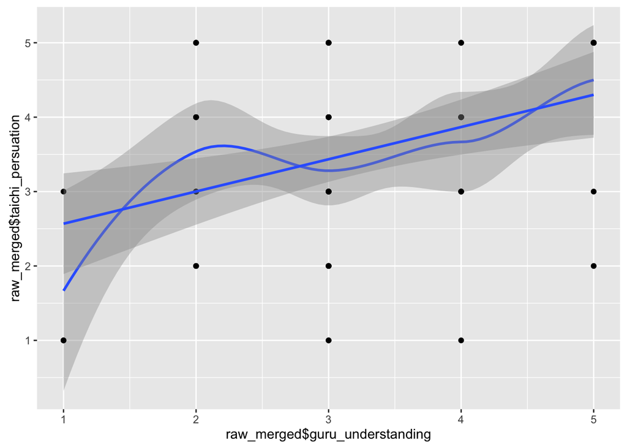

```r
qplot(raw_merged$guru_understanding, raw_merged$taichi_persuation,geom=c("smooth","point"))+
  geom_smooth(method='lm',formula=y~x)
```

Finally, let’s look at who’s persuaded by the dialogue system. The graph below illustrates the average interest in doing tai chi pre and post based on the type of exercise reported.

```
## No summary function supplied, defaulting to `mean_se()
```

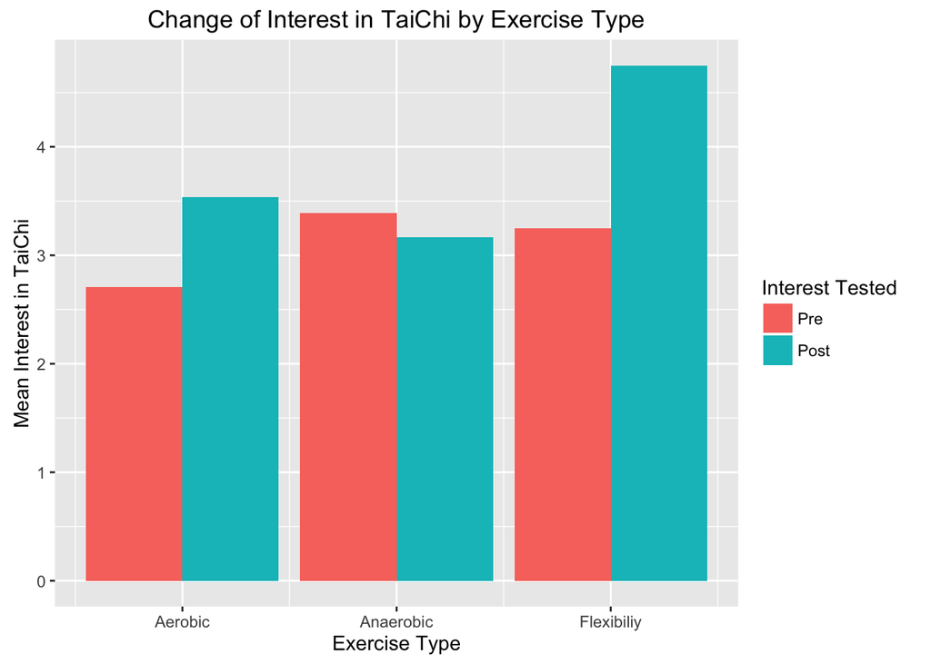

```r
d<-gather(raw_merged,interest,value,taichi_interest,taichi_learn)
ggplot(data=d,aes(x=excerise_time,y=value,fill=interest)) +
  geom_bar(stat="summary",position="dodge") +
  labs(title="Change of Interest in TaiChi by Exercise Type",y="Mean Interest in TaiChi")+
  scale_x_continuous(name="Exercise Type", breaks=c(1,2,3), labels=c("Aerobic","Anaerobic","Flexibiliy")) +
  scale_fill_discrete(name="Interest Tested",labels=c("Pre","Post"))
```

Finally, let’s look at who’s persuaded by the dialogue system. The graph below illustrates the average interest in doing tai chi pre and post based on the frequency of exercise reported.

```
## No summary function supplied, defaulting to `mean_se()
```

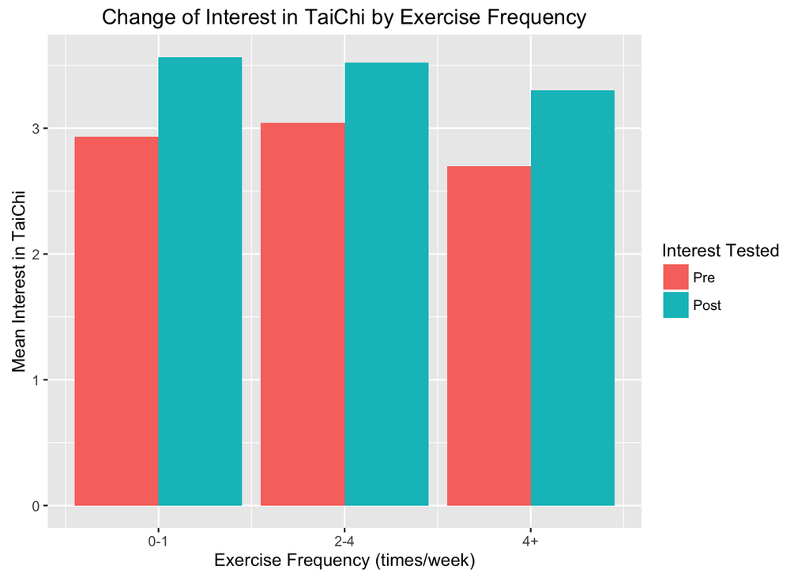

```r
d<-gather(raw_merged,interest,value,taichi_interest,taichi_learn)
ggplot(data=d,aes(x=excerise_freq,y=value,fill=interest)) +
  geom_bar(stat="summary",position="dodge") +
  labs(title="Change of Interest in TaiChi by Exercise Frequency",y="Mean Interest in TaiChi")+
  scale_x_continuous(name="Exercise Frequency (times/week)",breaks=c(1,2,3),labels=c("0-1","2-4","4+")) +
  scale_fill_discrete(name="Interest Tested",labels=c("Pre","Post"))
```